# LABORATORIO 9 - Gutierrez - Moscoso

**Laboratorio 9 - Redes Neuronales Artificiales**

**Integrantes:**

- Gutierrez Caceres, Claudia
- Moscoso Chumpitaz, Ricardo

**Parte A)**

Mediante la base a datos de cáncer de mama alojados en el repositorio UCI Machine Learning Repository utilizando la librería de Python ‘scikit-learn’, cree una red neuronal para clasificar a un paciente como canceroso o no canceroso de tal forma que obtenga el mayor valor de accuracy. Para ello, debe realizar el preprocesamiento de la información e ir ajustando la red neuronal con los parámetros requeridos como la cantidad de capas ocultas y neuronas por cada capa oculta, el número de iteraciones, la función de activación, el método para minimizar la función de error, entre otros.

```python
# Lectura de base de datos
import pandas as pd
data= pd.read_csv('cancer.csv')
data
```

|  | Unnamed: 0 | ClumpThick | UnifCellSize | UnifCellShape | MargAdh | SingEpiCellSize | BareNuclei | BlandChromatin | NormalNucleoli | Mitoses | Class |
| --- | --- | --- | --- | --- | --- | --- | --- | --- | --- | --- | --- |
| 0 | 0 | 5 | 1 | 1 | 1 | 2 | 1 | 3 | 1 | 1 | 0 |
| 1 | 1 | 5 | 4 | 4 | 5 | 7 | 10 | 3 | 2 | 1 | 0 |
| 2 | 2 | 3 | 1 | 1 | 1 | 2 | 2 | 3 | 1 | 1 | 0 |
| 3 | 3 | 6 | 8 | 8 | 1 | 3 | 4 | 3 | 7 | 1 | 0 |
| 4 | 4 | 4 | 1 | 1 | 3 | 2 | 1 | 3 | 1 | 1 | 0 |
| ... | ... | ... | ... | ... | ... | ... | ... | ... | ... | ... | ... |
| 694 | 694 | 3 | 1 | 1 | 1 | 3 | 2 | 1 | 1 | 1 | 0 |
| 695 | 695 | 2 | 1 | 1 | 1 | 2 | 1 | 1 | 1 | 1 | 0 |
| 696 | 696 | 5 | 10 | 10 | 3 | 7 | 3 | 8 | 10 | 2 | 1 |
| 697 | 697 | 4 | 8 | 6 | 4 | 3 | 4 | 10 | 6 | 1 | 1 |
| 698 | 698 | 4 | 8 | 8 | 5 | 4 | 5 | 10 | 4 | 1 | 1 |

699 rows × 11 columns

**Tratamiento de datos OUTLIERS**

**Detección de valores atípicos multivariados por medio de las distancias de Mahalanobis**

```python
# Separación de variables de datos atípicos
v_num = ['ClumpThick', 'UnifCellSize', 'UnifCellShape', 'MargAdh',
       'SingEpiCellSize', 'BareNuclei', 'BlandChromatin', 'NormalNucleoli','Mitoses']
from scipy.spatial.distance import mahalanobis
import scipy as sp
X = data[v_num]
Sx = X.cov().values
IC = sp.linalg.inv(Sx)
media = X.mean().values
```

```python
#Definición de la función
def mahalanobisR(X, media,IC):
    m = []
    for i in range (X.shape[0]):
        m.append(mahalanobis(X.iloc[i,:], media, IC)**2)
    return(m)
```

```python
# Hallamos las distancias de Mahalanobis
data['distMaha'] = pd.DataFrame(mahalanobisR(X,media,IC),columns = ['distMaha'])
data
```

|  | Unnamed: 0 | ClumpThick | UnifCellSize | UnifCellShape | MargAdh | SingEpiCellSize | BareNuclei | BlandChromatin | NormalNucleoli | Mitoses | Class | distMaha |
| --- | --- | --- | --- | --- | --- | --- | --- | --- | --- | --- | --- | --- |
| 0 | 0 | 5 | 1 | 1 | 1 | 2 | 1 | 3 | 1 | 1 | 0 | 2.138711 |
| 1 | 1 | 5 | 4 | 4 | 5 | 7 | 10 | 3 | 2 | 1 | 0 | 13.963588 |
| 2 | 2 | 3 | 1 | 1 | 1 | 2 | 2 | 3 | 1 | 1 | 0 | 1.082010 |
| 3 | 3 | 6 | 8 | 8 | 1 | 3 | 4 | 3 | 7 | 1 | 0 | 16.795995 |
| 4 | 4 | 4 | 1 | 1 | 3 | 2 | 1 | 3 | 1 | 1 | 0 | 2.230682 |
| ... | ... | ... | ... | ... | ... | ... | ... | ... | ... | ... | ... | ... |
| 694 | 694 | 3 | 1 | 1 | 1 | 3 | 2 | 1 | 1 | 1 | 0 | 1.756720 |
| 695 | 695 | 2 | 1 | 1 | 1 | 2 | 1 | 1 | 1 | 1 | 0 | 1.213823 |
| 696 | 696 | 5 | 10 | 10 | 3 | 7 | 3 | 8 | 10 | 2 | 1 | 20.004455 |
| 697 | 697 | 4 | 8 | 6 | 4 | 3 | 4 | 10 | 6 | 1 | 1 | 20.065667 |
| 698 | 698 | 4 | 8 | 8 | 5 | 4 | 5 | 10 | 4 | 1 | 1 | 18.161452 |

699 rows × 12 columns

**Eliminación de aquellos valores que superen el valor de 30**

```python
# Colocación de los índices
data['index'] = data.index
data
```

|  | Unnamed: 0 | ClumpThick | UnifCellSize | UnifCellShape | MargAdh | SingEpiCellSize | BareNuclei | BlandChromatin | NormalNucleoli | Mitoses | Class | distMaha | index |
| --- | --- | --- | --- | --- | --- | --- | --- | --- | --- | --- | --- | --- | --- |
| 0 | 0 | 5 | 1 | 1 | 1 | 2 | 1 | 3 | 1 | 1 | 0 | 2.138711 | 0 |
| 1 | 1 | 5 | 4 | 4 | 5 | 7 | 10 | 3 | 2 | 1 | 0 | 13.963588 | 1 |
| 2 | 2 | 3 | 1 | 1 | 1 | 2 | 2 | 3 | 1 | 1 | 0 | 1.082010 | 2 |
| 3 | 3 | 6 | 8 | 8 | 1 | 3 | 4 | 3 | 7 | 1 | 0 | 16.795995 | 3 |
| 4 | 4 | 4 | 1 | 1 | 3 | 2 | 1 | 3 | 1 | 1 | 0 | 2.230682 | 4 |
| ... | ... | ... | ... | ... | ... | ... | ... | ... | ... | ... | ... | ... | ... |
| 694 | 694 | 3 | 1 | 1 | 1 | 3 | 2 | 1 | 1 | 1 | 0 | 1.756720 | 694 |
| 695 | 695 | 2 | 1 | 1 | 1 | 2 | 1 | 1 | 1 | 1 | 0 | 1.213823 | 695 |
| 696 | 696 | 5 | 10 | 10 | 3 | 7 | 3 | 8 | 10 | 2 | 1 | 20.004455 | 696 |
| 697 | 697 | 4 | 8 | 6 | 4 | 3 | 4 | 10 | 6 | 1 | 1 | 20.065667 | 697 |
| 698 | 698 | 4 | 8 | 8 | 5 | 4 | 5 | 10 | 4 | 1 | 1 | 18.161452 | 698 |

699 rows × 13 columns

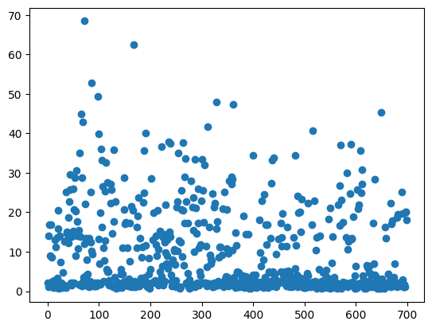

```python
#Gráfico de distancias de Mahalanobis
data['index']=data.index
import matplotlib.pyplot as plt
plt.scatter(data["index"],data['distMaha'])
```

```python
# Detección de data a eliminar
data_elim = data[data['distMaha']>30]
len(data_elim)
```

```
38
```

```python
# Guardamos sus ubicaciones
elim = data_elim['index']
elim
```

```
56      56
62      62
65      65
68      68
71      71
85      85
98      98
100    100
104    104
106    106
113    113
129    129
167    167
187    187
191    191
```

[output cut: 24 more lines]

```python
# Eliminación  de los datos
data = data.drop(elim, axis=0)
data = data.drop(['distMaha','index','Unnamed: 0'], axis = 1) # 'Unnamed: 0' también ya que no es una columna relevante
data
```

|  | ClumpThick | UnifCellSize | UnifCellShape | MargAdh | SingEpiCellSize | BareNuclei | BlandChromatin | NormalNucleoli | Mitoses | Class |
| --- | --- | --- | --- | --- | --- | --- | --- | --- | --- | --- |
| 0 | 5 | 1 | 1 | 1 | 2 | 1 | 3 | 1 | 1 | 0 |
| 1 | 5 | 4 | 4 | 5 | 7 | 10 | 3 | 2 | 1 | 0 |
| 2 | 3 | 1 | 1 | 1 | 2 | 2 | 3 | 1 | 1 | 0 |
| 3 | 6 | 8 | 8 | 1 | 3 | 4 | 3 | 7 | 1 | 0 |
| 4 | 4 | 1 | 1 | 3 | 2 | 1 | 3 | 1 | 1 | 0 |
| ... | ... | ... | ... | ... | ... | ... | ... | ... | ... | ... |
| 694 | 3 | 1 | 1 | 1 | 3 | 2 | 1 | 1 | 1 | 0 |
| 695 | 2 | 1 | 1 | 1 | 2 | 1 | 1 | 1 | 1 | 0 |
| 696 | 5 | 10 | 10 | 3 | 7 | 3 | 8 | 10 | 2 | 1 |
| 697 | 4 | 8 | 6 | 4 | 3 | 4 | 10 | 6 | 1 | 1 |
| 698 | 4 | 8 | 8 | 5 | 4 | 5 | 10 | 4 | 1 | 1 |

661 rows × 10 columns

**Balanceo de clases**

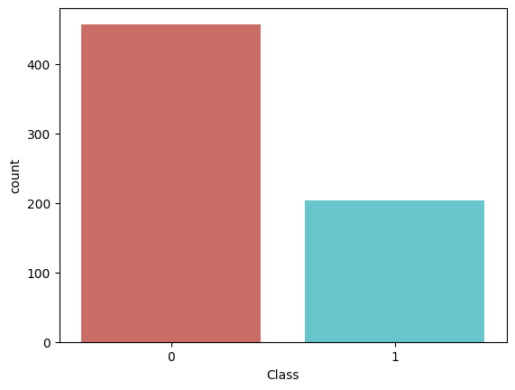

```
0    457
1    204
Name: Class, dtype: int64
```

```python
# Verificamos las clases
import seaborn as sns
import matplotlib.pyplot as plt
sns.countplot(x='Class',data=data,palette='hls')
plt.show()
print(data['Class'].value_counts())
```

```python
# Definimos los datasets

X = data[v_num]
y = data['Class']
```

```
Cantidad antes del SMOTE Counter({0: 457, 1: 204})
Cantidad después del SMOTE Counter({0: 457, 1: 457})
Comprobación gráfica:
```

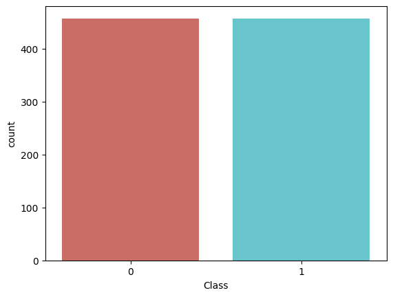

```
0    457
1    457
Name: Class, dtype: int64
```

```python
# Instalamos e importamos la función SMOTE, balanceamos y verificamos gráficamente
#!pip install imbalanced-learn
from imblearn.over_sampling import SMOTE
from collections import Counter

smote=SMOTE(sampling_strategy='minority')
X_bal, y_bal =smote.fit_resample(X,y)# Pasar los datos a balancear, los datos de prueba se usaran para las predicciones, se podria usar la data original
print('Cantidad antes del SMOTE {}'.format(Counter(y)))
print('Cantidad después del SMOTE {}'.format(Counter(y_bal)))

print('Comprobación gráfica: ')
sns.countplot(x=y_bal, data=data,palette='hls')
plt.show()
print(y_bal.value_counts())
```

```python
# Unimos  las variables balaceadas en un dataframe
data = pd.concat([X_bal, y_bal],axis=1)
data
```

|  | ClumpThick | UnifCellSize | UnifCellShape | MargAdh | SingEpiCellSize | BareNuclei | BlandChromatin | NormalNucleoli | Mitoses | Class |
| --- | --- | --- | --- | --- | --- | --- | --- | --- | --- | --- |
| 0 | 5 | 1 | 1 | 1 | 2 | 1 | 3 | 1 | 1 | 0 |
| 1 | 5 | 4 | 4 | 5 | 7 | 10 | 3 | 2 | 1 | 0 |
| 2 | 3 | 1 | 1 | 1 | 2 | 2 | 3 | 1 | 1 | 0 |
| 3 | 6 | 8 | 8 | 1 | 3 | 4 | 3 | 7 | 1 | 0 |
| 4 | 4 | 1 | 1 | 3 | 2 | 1 | 3 | 1 | 1 | 0 |
| ... | ... | ... | ... | ... | ... | ... | ... | ... | ... | ... |
| 909 | 10 | 3 | 3 | 4 | 3 | 10 | 4 | 1 | 1 | 1 |
| 910 | 7 | 5 | 3 | 10 | 6 | 9 | 5 | 4 | 4 | 1 |
| 911 | 6 | 5 | 6 | 9 | 4 | 10 | 5 | 3 | 1 | 1 |
| 912 | 6 | 4 | 6 | 1 | 3 | 10 | 3 | 7 | 1 | 1 |
| 913 | 10 | 8 | 8 | 1 | 3 | 10 | 4 | 1 | 1 | 1 |

914 rows × 10 columns

```python
# Verificamos la variable de clasificación
data['Class'].unique()
```

```
array([0, 1])
```

**Datos de almacenamiento y prueba**

```python
v_numericas = data[["ClumpThick", "UnifCellSize", "UnifCellShape", "MargAdh", "SingEpiCellSize", "BareNuclei", "BlandChromatin", "NormalNucleoli", "Mitoses"]]
v_numericas = list(v_numericas.columns.values)
v_numericas

X = data[v_numericas]
y = data['Class']
```

```python
# Dividimos la data en data test (20%) y data train
from sklearn.model_selection import train_test_split
X_train,X_test,y_train, y_test = train_test_split(X,y,test_size=0.20,random_state=99)
X_test,y_train
```

```
(     ClumpThick  UnifCellSize  UnifCellShape  MargAdh  SingEpiCellSize  \
 211           8             9              9        5                3
 838           8            10             10        8                6
 143           5             5              5        6                3
 588           3             1              3        1                3
 889          10             4              6        2                3
 ..          ...           ...            ...      ...              ...
 819          10             4              5        5                5
 660           4             8              8        5                4
 476           1             1              1        1                2
 627           1             1              1        1                2
 167           1             1              1        1                1

      BareNuclei  BlandChromatin  NormalNucleoli  Mitoses
 211           5               7               7        1
```

[output cut: 24 more lines]

```python
from sklearn.preprocessing import StandardScaler
scaler=StandardScaler()
scaler.fit(X_train)
X_train=scaler.transform(X_train)
X_test=scaler.transform(X_test)
```

**RED NEURONAL DE CLASIFICACIÓN**

```python
from sklearn.neural_network import MLPClassifier
RNA_clf=MLPClassifier(hidden_layer_sizes=(500,500,500),max_iter=10000,alpha=0.0001,activation="tanh",
                     solver="adam",random_state=38,tol=0.000000001)
RNA_clf.fit(X_train,y_train)
```

```
MLPClassifier(activation='tanh', hidden_layer_sizes=(500, 500, 500),
              max_iter=10000, random_state=38, tol=1e-09)
```

```python
y_prob=RNA_clf.predict_proba(X_test)
y_pred=RNA_clf.predict(X_test)
```

**Mayor accuracy posible**

```python
pd.crosstab(y_test,y_pred,rownames=['Verdaderos'],colnames=['Predichos'])
from sklearn.metrics import accuracy_score,precision_score,recall_score,f1_score
print('Exactitud = ',accuracy_score(y_test,y_pred))
print('Precisión = ',precision_score(y_test,y_pred))
print('Sensibilidad =',recall_score(y_test,y_pred))
print('Puntuación F1 =',f1_score(y_test,y_pred))
```

```
Exactitud =  0.9726775956284153
Precisión =  0.946236559139785
Sensibilidad = 1.0
Puntuación F1 = 0.9723756906077349
```

**Parte B)**

Tome la base de datos llamada ‘Fashion MNIST’ (https://github.com/zalandoresearch/fashionmnist) la cual consiste de 60 000 fotos (28×28 pixeles por cada imagen) de prendas de ropa e importándola directamente desde ‘keras’, cree una red neuronal convolucional que sirva para clasificar las imágenes respecto al tipo de ropa mostrado (10 tipos distintos de artículos) de tal forma que se obtenga el mayor valor de accuracy. Para ello, deberá ir ajustando la red neuronal con los parámetros requeridos como la cantidad de capas ocultas y neuronas por cada capa oculta, el número de iteraciones, la función de activación, el método para minimizar la función de error, entre otros.

**Importamos librerias**

```python
import tensorflow as tf
from tensorflow import  keras
import matplotlib.pyplot as plt

from keras.api._v2.keras.datasets import fashion_mnist
fashion_mnist=keras.datasets.fashion_mnist
(X_train,y_train),(X_test,y_test)=fashion_mnist.load_data()
```

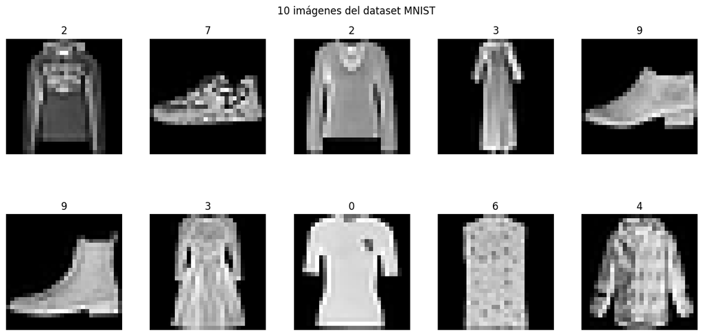

```python
import matplotlib.pyplot as plt
import numpy as np

ids_imgs = np.random.randint(0, X_train.shape[0], 10)
fig = plt.figure(figsize=(12, 12))
for i in range(len(ids_imgs)):
    plt.suptitle('10 imágenes del dataset MNIST')
    img = X_train[ids_imgs[i], :, :]
    plt.subplot(4, 5, i + 1)  # Acomoda las 19 imágenes en 4 filas y 5 columnas
    fig.tight_layout()

    plt.imshow(img, cmap='gray')
    plt.axis('off')
    plt.title(y_train[ids_imgs[i]])

plt.show()
```

```python
X_train = np.reshape(X_train, (X_train.shape[0],X_train.shape[1]*X_train.shape[2]))
X_test = np.reshape(X_test, (X_test.shape[0],X_test.shape[1]*X_test.shape[2]))
```

```python
X_train=X_train/255.0
X_test = X_test/255.0
```

```python
from tensorflow.keras.utils import to_categorical
nclasses= 10
y_train =to_categorical (y_train, nclasses)
y_test=to_categorical (y_test,nclasses)
```

```python
np.random.seed(1)
input_dim= X_train.shape[1]
output_dim= y_train.shape[1]
```

```python
from tensorflow.keras.models import Sequential
from tensorflow.keras.layers import Dense
modelo=Sequential()
modelo.add(Dense(15,input_dim=input_dim, activation='relu'))
modelo.add(Dense(output_dim, activation='softmax'))
```

```python
from tensorflow.keras.optimizers import SGD
sgd=SGD(lr=0.2)
modelo.compile(loss='categorical_crossentropy',optimizer=sgd,metrics=['accuracy'])
```

```
WARNING:absl:`lr` is deprecated in Keras optimizer, please use `learning_rate` or use the legacy optimizer, e.g.,tf.keras.optimizers.legacy.SGD.
```

```python
historia = modelo.fit(X_train, y_train, epochs=90, batch_size=1024, verbose=2)
```

```
59/59 - 1s - loss: 2.1307 - accuracy: 0.2110 - 847ms/epoch - 14ms/step
59/59 - 0s - loss: 1.7680 - accuracy: 0.4365 - 326ms/epoch - 6ms/step
59/59 - 0s - loss: 1.4768 - accuracy: 0.5707 - 357ms/epoch - 6ms/step
59/59 - 0s - loss: 1.2596 - accuracy: 0.6533 - 328ms/epoch - 6ms/step
59/59 - 0s - loss: 1.1045 - accuracy: 0.6826 - 331ms/epoch - 6ms/step
59/59 - 0s - loss: 0.9954 - accuracy: 0.7062 - 333ms/epoch - 6ms/step
59/59 - 0s - loss: 0.9176 - accuracy: 0.7235 - 324ms/epoch - 5ms/step
59/59 - 0s - loss: 0.8602 - accuracy: 0.7365 - 334ms/epoch - 6ms/step
59/59 - 0s - loss: 0.8165 - accuracy: 0.7465 - 332ms/epoch - 6ms/step
59/59 - 0s - loss: 0.7822 - accuracy: 0.7553 - 313ms/epoch - 5ms/step
59/59 - 0s - loss: 0.7543 - accuracy: 0.7610 - 311ms/epoch - 5ms/step
59/59 - 0s - loss: 0.7312 - accuracy: 0.7668 - 318ms/epoch - 5ms/step
59/59 - 0s - loss: 0.7115 - accuracy: 0.7721 - 319ms/epoch - 5ms/step
59/59 - 0s - loss: 0.6947 - accuracy: 0.7761 - 327ms/epoch - 6ms/step
59/59 - 0s - loss: 0.6799 - accuracy: 0.7805 - 324ms/epoch - 5ms/step
59/59 - 0s - loss: 0.6669 - accuracy: 0.7835 - 329ms/epoch - 6ms/step
59/59 - 0s - loss: 0.6553 - accuracy: 0.7865 - 382ms/epoch - 6ms/step
59/59 - 1s - loss: 0.6450 - accuracy: 0.7896 - 511ms/epoch - 9ms/step
59/59 - 0s - loss: 0.6355 - accuracy: 0.7926 - 462ms/epoch - 8ms/step
59/59 - 0s - loss: 0.6269 - accuracy: 0.7948 - 471ms/epoch - 8ms/step
59/59 - 0s - loss: 0.6190 - accuracy: 0.7969 - 493ms/epoch - 8ms/step
59/59 - 0s - loss: 0.6117 - accuracy: 0.7993 - 478ms/epoch - 8ms/step
59/59 - 0s - loss: 0.6051 - accuracy: 0.8011 - 425ms/epoch - 7ms/step
59/59 - 0s - loss: 0.5988 - accuracy: 0.8037 - 308ms/epoch - 5ms/step
59/59 - 0s - loss: 0.5931 - accuracy: 0.8049 - 315ms/epoch - 5ms/step
59/59 - 0s - loss: 0.5877 - accuracy: 0.8063 - 315ms/epoch - 5ms/step
59/59 - 0s - loss: 0.5826 - accuracy: 0.8074 - 316ms/epoch - 5ms/step
59/59 - 0s - loss: 0.5778 - accuracy: 0.8094 - 301ms/epoch - 5ms/step
59/59 - 0s - loss: 0.5734 - accuracy: 0.8100 - 314ms/epoch - 5ms/step
59/59 - 0s - loss: 0.5692 - accuracy: 0.8115 - 306ms/epoch - 5ms/step
59/59 - 0s - loss: 0.5653 - accuracy: 0.8119 - 310ms/epoch - 5ms/step
59/59 - 0s - loss: 0.5614 - accuracy: 0.8134 - 317ms/epoch - 5ms/step
59/59 - 0s - loss: 0.5578 - accuracy: 0.8141 - 313ms/epoch - 5ms/step
59/59 - 0s - loss: 0.5544 - accuracy: 0.8156 - 314ms/epoch - 5ms/step
59/59 - 0s - loss: 0.5510 - accuracy: 0.8166 - 336ms/epoch - 6ms/step
59/59 - 0s - loss: 0.5480 - accuracy: 0.8165 - 323ms/epoch - 5ms/step
59/59 - 0s - loss: 0.5450 - accuracy: 0.8180 - 325ms/epoch - 6ms/step
59/59 - 0s - loss: 0.5423 - accuracy: 0.8187 - 314ms/epoch - 5ms/step
59/59 - 0s - loss: 0.5395 - accuracy: 0.8194 - 319ms/epoch - 5ms/step
59/59 - 0s - loss: 0.5369 - accuracy: 0.8207 - 308ms/epoch - 5ms/step
```

[output cut: 35 more lines]

```
59/59 - 0s - loss: 0.4815 - accuracy: 0.8370 - 310ms/epoch - 5ms/step
59/59 - 0s - loss: 0.4807 - accuracy: 0.8372 - 321ms/epoch - 5ms/step
59/59 - 0s - loss: 0.4797 - accuracy: 0.8379 - 311ms/epoch - 5ms/step
59/59 - 0s - loss: 0.4788 - accuracy: 0.8377 - 315ms/epoch - 5ms/step
59/59 - 0s - loss: 0.4780 - accuracy: 0.8379 - 321ms/epoch - 5ms/step
59/59 - 0s - loss: 0.4770 - accuracy: 0.8384 - 330ms/epoch - 6ms/step
59/59 - 0s - loss: 0.4763 - accuracy: 0.8382 - 339ms/epoch - 6ms/step
59/59 - 0s - loss: 0.4754 - accuracy: 0.8390 - 323ms/epoch - 5ms/step
59/59 - 0s - loss: 0.4746 - accuracy: 0.8393 - 320ms/epoch - 5ms/step
59/59 - 0s - loss: 0.4738 - accuracy: 0.8394 - 320ms/epoch - 5ms/step
59/59 - 0s - loss: 0.4728 - accuracy: 0.8398 - 321ms/epoch - 5ms/step
59/59 - 0s - loss: 0.4722 - accuracy: 0.8398 - 331ms/epoch - 6ms/step
59/59 - 0s - loss: 0.4714 - accuracy: 0.8401 - 323ms/epoch - 5ms/step
59/59 - 0s - loss: 0.4706 - accuracy: 0.8404 - 332ms/epoch - 6ms/step
59/59 - 0s - loss: 0.4699 - accuracy: 0.8407 - 322ms/epoch - 5ms/step
```

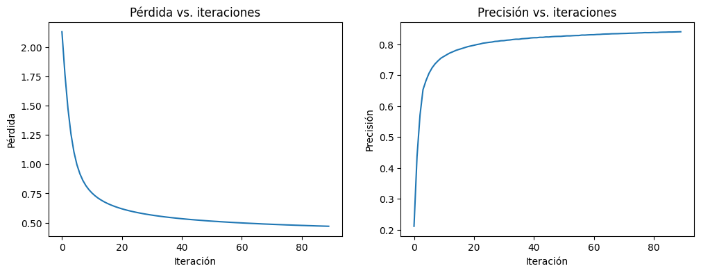

```python
fig = plt.figure(figsize=(12,4))

plt.subplot(1,2,1)
plt.plot(historia.history['loss'])
plt.title('Pérdida vs. iteraciones')
plt.ylabel('Pérdida')
plt.xlabel('Iteración')

plt.subplot(1,2,2)
plt.plot(historia.history['accuracy'])
plt.title('Precisión vs. iteraciones')
plt.ylabel('Precisión')
plt.xlabel('Iteración')
plt.show()
```

**Mayor accuracy posible**

```python
accuracy = modelo.evaluate(X_test,y_test, verbose=0)
print('Precisión en el set de validación: {:.1f}%'.format(100*accuracy[1]))
```

```
Precisión en el set de validación: 82.8%
```

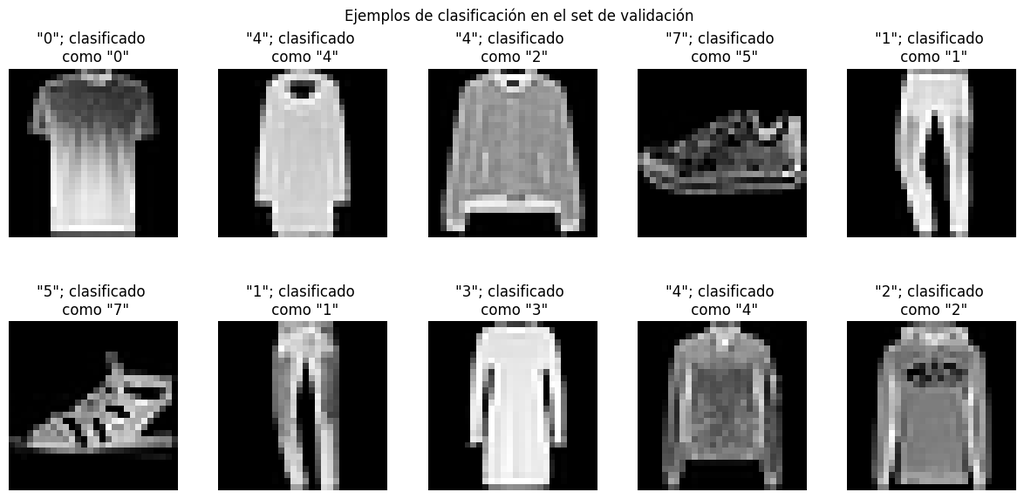

```python
y_pred = np.argmax(modelo.predict(X_test), axis=-1)
ids_imgs = np.random.randint(0,X_test.shape[0],10)
fig = plt.figure(figsize=(12,12))
for i in range(len(ids_imgs)):
  plt.suptitle('Ejemplos de clasificación en el set de validación')
  idx= ids_imgs[i]
  img = X_test[idx,:].reshape(28,28)
  cat_original = np.argmax(y_test[idx,:])
  cat_prediccion = y_pred[idx]
  plt.subplot(4, 5, i + 1)
  plt.tight_layout()
  plt.imshow(img, cmap='gray')
  plt.axis('off')
  plt.title('"{}"; clasificado \n como "{}"'.format(cat_original,cat_prediccion))
plt.show()
```